# Predicting Activities With Fitness Device Data

Michael Sieviec

9/12/2019

## 2. Gathering, Cleaning, and Assembling the Data

```r
library(caret)
library(kableExtra)
library(ggplot2)
library(magrittr)
library(mice)
library(nnet)
library(randomForest)
library(reshape2)
library(tidyverse)
set.seed(555)
knitr::opts_chunk$set(echo = TRUE,fig.pos = 'H')
```

```r
download.file(url="https://d396qusza40orc.cloudfront.net/predmachlearn/pml-training.csv",
              method="curl",destfile="training.csv")
training <- read.csv("training.csv", na.strings = c("", "NA")) %>% as_tibble()
dim(training)
```

```
## [1] 19622   160
```

We see the data contains 19622 rows and 160 variables.

```r
# Proportion of NA Values
sum(is.na(training))/(dim(training)[1]*dim(training)[2])
```

```
## [1] 0.6120681
```

More than 61% of the data was found to be missing, which is enough to have a large effect on the models.

```r
missing <- md.pattern(training, plot = FALSE)
missing[,ncol(missing)]
```

```
##     406   19216
##       0     100 1921600
```

Only 406 rows are missing no variables, but 19216 rows–nearly 98%–are missing 100 variables. Inspecting the `md.pattern` output reveals that these missing values are limited to 100 variables exactly–that is, they’re conveniently not dispersed throughout all of the data. So, we will simply drop the variables from the data as imputing those values would be problematic.

```r
dropVars <- names(training)[which(missing == 19216, arr.ind = T)[,'col']]
dropVars <- which(missing == 0, arr.ind = T) %>%
  as_tibble() %>%
  filter(row == 2)
dropVars <- colnames(missing[,dropVars$col])
training <- training %>% select(-dropVars)
```

Next, the first seven variables are removed from the data as they are not fitness device measurements, and we will rename the `classe` variable.

```r
training <- training %>%
  select(-c(1:7)) %>%
  rename(class = classe)
training %>% head() %>%
  kable(booktabs = TRUE, caption = 'Table 1: Sample of Training Data') %>%
  kable_styling() %>%
  scroll_box(width = '100%')
```

Table 1: Sample of Training Data

| roll_belt | pitch_belt | yaw_belt | total_accel_belt | gyros_belt_x | gyros_belt_y | gyros_belt_z | accel_belt_x | accel_belt_y | accel_belt_z | magnet_belt_x | magnet_belt_y | magnet_belt_z | roll_arm | pitch_arm | yaw_arm | total_accel_arm | gyros_arm_x | gyros_arm_y | gyros_arm_z | accel_arm_x | accel_arm_y | accel_arm_z | magnet_arm_x | magnet_arm_y | magnet_arm_z | roll_dumbbell | pitch_dumbbell | yaw_dumbbell | total_accel_dumbbell | … |
| --- | --- | --- | --- | --- | --- | --- | --- | --- | --- | --- | --- | --- | --- | --- | --- | --- | --- | --- | --- | --- | --- | --- | --- | --- | --- | --- | --- | --- | --- | --- |
| 1.41 | 8.07 | -94.4 | 3 | 0.00 | 0.00 | -0.02 | -21 | 4 | 22 | -3 | 599 | -313 | -128 | 22.5 | -161 | 34 | 0.00 | 0.00 | -0.02 | -288 | 109 | -123 | -368 | 337 | 516 | 13.05217 | -70.49400 | -84.87394 | 37 | … |
| 1.41 | 8.07 | -94.4 | 3 | 0.02 | 0.00 | -0.02 | -22 | 4 | 22 | -7 | 608 | -311 | -128 | 22.5 | -161 | 34 | 0.02 | -0.02 | -0.02 | -290 | 110 | -125 | -369 | 337 | 513 | 13.13074 | -70.63751 | -84.71065 | 37 | … |
| 1.42 | 8.07 | -94.4 | 3 | 0.00 | 0.00 | -0.02 | -20 | 5 | 23 | -2 | 600 | -305 | -128 | 22.5 | -161 | 34 | 0.02 | -0.02 | -0.02 | -289 | 110 | -126 | -368 | 344 | 513 | 12.85075 | -70.27812 | -85.14078 | 37 | … |
| 1.48 | 8.05 | -94.4 | 3 | 0.02 | 0.00 | -0.03 | -22 | 3 | 21 | -6 | 604 | -310 | -128 | 22.1 | -161 | 34 | 0.02 | -0.03 | 0.02 | -289 | 111 | -123 | -372 | 344 | 512 | 13.43120 | -70.39379 | -84.87363 | 37 | … |
| 1.48 | 8.07 | -94.4 | 3 | 0.02 | 0.02 | -0.02 | -21 | 2 | 24 | -6 | 600 | -302 | -128 | 22.1 | -161 | 34 | 0.00 | -0.03 | 0.00 | -289 | 111 | -123 | -374 | 337 | 506 | 13.37872 | -70.42856 | -84.85306 | 37 | … |
| 1.45 | 8.06 | -94.4 | 3 | 0.02 | 0.00 | -0.02 | -21 | 4 | 21 | 0 | 603 | -312 | -128 | 22.0 | -161 | 34 | 0.02 | -0.03 | 0.00 | -289 | 111 | -122 | -369 | 342 | 513 | 13.38246 | -70.81759 | -84.46500 | 37 | … |

Much better.

## 3. Prediction Modeling

```r
training %>% group_by(class) %>%
  summarise(n()/nrow(training)) %>%
  kable(booktabs = T, caption = 'Table 2: Proportion of Observations for Each Activity',
        col.names = c('Class', 'Proportion'), width = '50%') %>%
  kable_styling(full_width = F) %>%
  column_spec(2, width = '14em')
```

Table 2: Proportion of Observations for Each Activity

| Class | Proportion |
| --- | --- |
| A | 0.2843747 |
| B | 0.1935073 |
| C | 0.1743961 |
| D | 0.1638977 |
| E | 0.1838243 |

We see the proportions are not exactly balanced, so we will use [Cohen’s Kappa](https://en.wikipedia.org/wiki/Cohen%27s_kappa) to evaluate our models’ performance.

The data are partitioned into a 70% training and a 30% testing set.

```r
forTraining <- createDataPartition(training$class,p=0.7,list=FALSE)
testing <- training[-forTraining,]
training <- training[forTraining,]
```

We’re going to compare a random forest model with a bagged tree model. The main difference between these two methods is that a random forest builds its decision trees on some subset of the variables, whereas a bagged trees model builds its using all of the variables, as illustrated in this image:

Figure 1: Random Forest vs. Bagged Trees Methodology

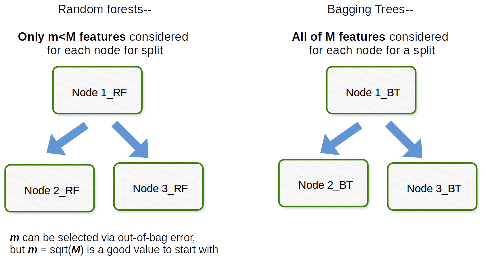

```r
model.rf <- randomForest(class ~ ., data = training, ntree = 50)
model.bag <- randomForest(class ~ ., data = training,
                         ntree = 50, mtry = ncol(training %>% select(-class)))
```

Predictions are then generated.

```r
predict.rf <- predict(model.rf, testing %>% select(-class))
predict.bag <- predict(model.bag, testing %>% select(-class))
```

### Model Accuracy

#### Training Set

```r
model.rf %>% capture.output() %>%
  .[c(6,8)] %>%
  str_trim() %>%
  paste('Random forest: ',.) %>%
  noquote()
```

```
## [1] Random forest:  No. of variables tried at each split: 7
## [2] Random forest:  OOB estimate of  error rate: 0.7%
```

```r
model.bag %>% capture.output() %>%
  .[c(6,8)] %>%
  str_trim() %>%
  paste('Bagged trees: ',.) %>%
  noquote()
```

```
## [1] Bagged trees:  No. of variables tried at each split: 52
## [2] Bagged trees:  OOB estimate of  error rate: 1.23%
```

We see that using only 7 variables at each split, the random forest model achieved an estimated OOB error rate of 0.7%, compared with the bagged trees error rate of 1.23%. This discrepancy is likely due to overfitting with bagged trees, however both are excellent models.

#### Testing Set

```r
conf.rf <- confusionMatrix(predict.rf, testing$class)
conf.bag <- confusionMatrix(predict.bag, testing$class)
paste('Random forest Kappa:',conf.rf$overall[2] %>% round(.,3)) %>% noquote()
```

```
## [1] Random forest Kappa: 0.993
```

```r
paste('Bagged trees Kappa:',conf.bag$overall[2] %>% round(.,3)) %>% noquote()
```

```
## [1] Bagged trees Kappa: 0.988
```

We see that they each perform similarly well on the test set, with the Kappas being extremely high.

### Heatmaps

Below are heatmaps of each prediction models’ respective confusion matrix against the training and testing data.

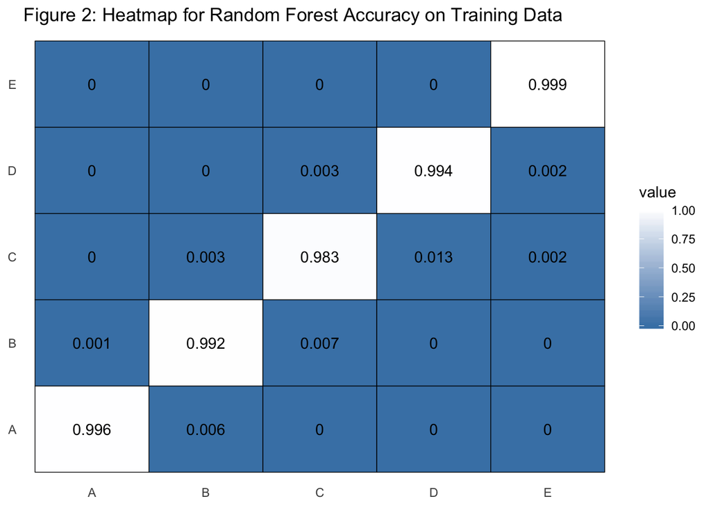

```r
melted.rf <- melt(model.rf$confusion[,1:5]/colSums(model.rf$confusion[,1:5]))
plot.rf <- ggplot(data.frame(melted.rf),
                  aes(x=Var1, y=Var2, fill=value)) +
  geom_tile(color = 'black', size = 0.25) +
  scale_fill_gradient(low = "steelblue",high = "white", limits = c(0,1)) +
  ggtitle("Figure 2: Heatmap for Random Forest Accuracy on Training Data") +
  geom_text(aes(label=round(value,3))) +
  theme(axis.title = element_blank(),
        panel.background = element_blank(),
        axis.ticks = element_blank())
plot.rf
```

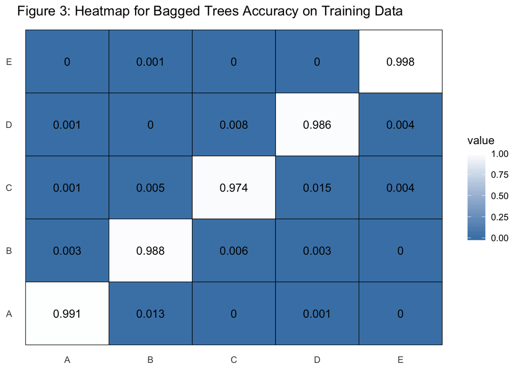

```r
melted.bag <- melt(model.bag$confusion[,1:5]/colSums(model.bag$confusion[,1:5]))
plot.bag <- ggplot(data.frame(melted.bag),
                    aes(x=Var1, y=Var2, fill=value)) +
  geom_tile(color = 'black', size = 0.25) +
  scale_fill_gradient(low = "steelblue",high = "white", limits = c(0,1)) +
  ggtitle("Figure 3: Heatmap for Bagged Trees Accuracy on Training Data") +
  geom_text(aes(label=round(value,3))) +
  theme(axis.title = element_blank(),
        panel.background = element_blank(),
        axis.ticks = element_blank())
plot.bag
```

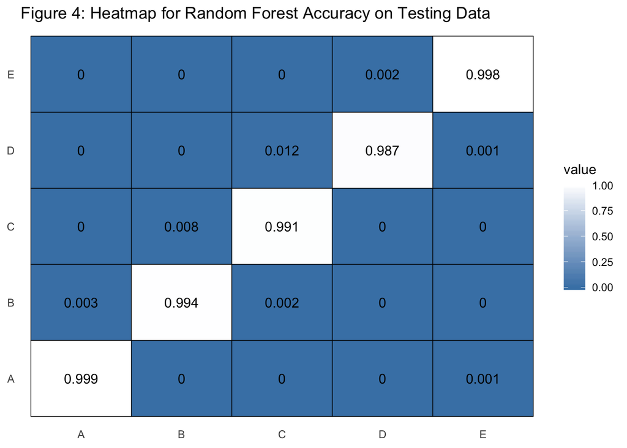

```r
melted.rf <- melt(conf.rf$table/colSums(conf.rf$table))
plot.rf <- ggplot(data.frame(melted.rf),
                  aes(x=Prediction, y=Reference, fill=value)) +
  geom_tile(color = 'black', size = 0.25) +
  scale_fill_gradient(low = "steelblue",high = "white", limits = c(0,1)) +
  ggtitle("Figure 4: Heatmap for Random Forest Accuracy on Testing Data") +
  geom_text(aes(label=round(value,3))) +
  theme(axis.title = element_blank(),
        panel.background = element_blank(),
        axis.ticks = element_blank())
plot.rf
```

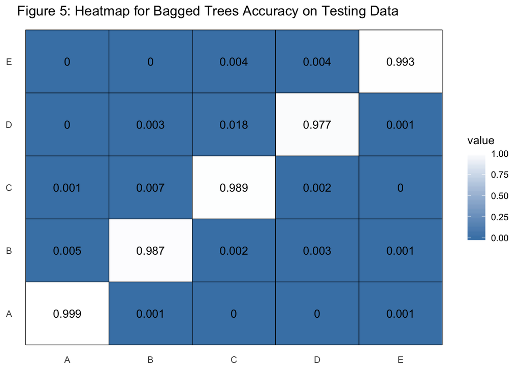

```r
melted.bag <- melt(conf.bag$table/colSums(conf.bag$table))
plot.bag <- ggplot(data.frame(melted.bag),
                    aes(x=Prediction, y=Reference, fill=value)) +
  geom_tile(color = 'black', size = 0.25) +
  scale_fill_gradient(low = "steelblue",high = "white", limits = c(0,1)) +
  ggtitle("Figure 5: Heatmap for Bagged Trees Accuracy on Testing Data") +
  geom_text(aes(label=round(value,3))) +
  theme(axis.title = element_blank(),
        panel.background = element_blank(),
        axis.ticks = element_blank())
plot.bag
```

### Important Features

```r
imp.rf <- bind_cols(Feature = model.rf$importance %>% rownames(),
                    model.rf$importance %>% as_tibble()) %>%
  arrange(desc(MeanDecreaseGini))
imp.rf %<>% mutate(MeanDecreaseGini = MeanDecreaseGini/sum(MeanDecreaseGini)) %>%
  slice(1:10)
imp.bag <- bind_cols(Feature = model.bag$importance %>% rownames(),
                     model.bag$importance %>% as_tibble()) %>%
  arrange(desc(MeanDecreaseGini))
imp.bag %<>% mutate(MeanDecreaseGini = MeanDecreaseGini/sum(MeanDecreaseGini)) %>%
  slice(1:10)

source('palettes.R') #import color palettes for feature matching
```

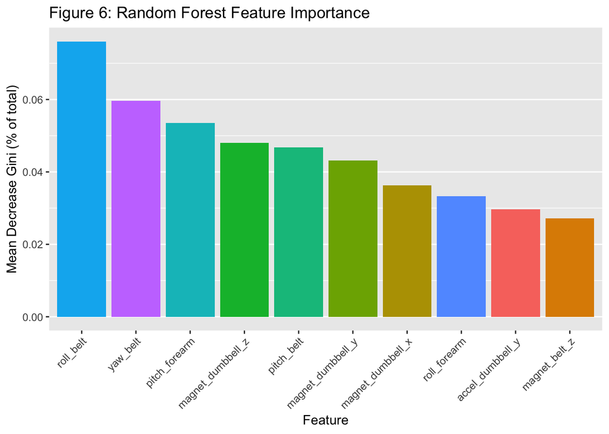

```r
imp.rf %>% ggplot(., aes(x = reorder(Feature, -MeanDecreaseGini),
                                y = MeanDecreaseGini,
                                fill = Feature)) +
  geom_col() +
  theme(axis.text.x = element_text(angle = 45, hjust = 1, vjust = 1),
        panel.grid.major.x = element_blank()) +
  xlab('Feature') +
  ylab('Mean Decrease Gini (% of total)') +
  ggtitle('Figure 6: Random Forest Feature Importance') +
  scale_fill_manual(values = pal.rf) +
  theme(legend.position = 'none')
```

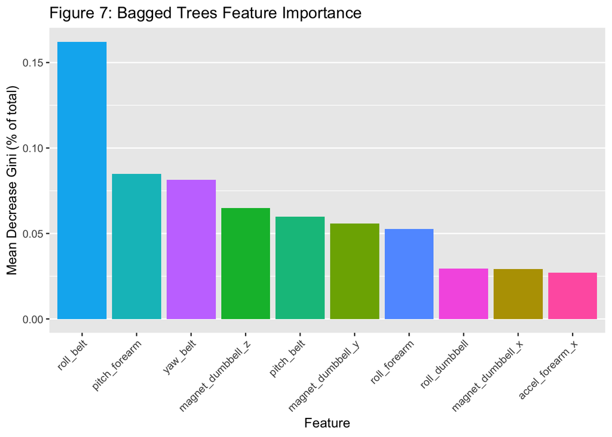

```r
imp.bag %>% ggplot(., aes(x = reorder(Feature, -MeanDecreaseGini),
                                y = MeanDecreaseGini,
                                fill = Feature)) +
  geom_col() +
  theme(axis.text.x = element_text(angle = 45, hjust = 1, vjust = 1),
        panel.grid.major.x = element_blank()) +
  xlab('Feature') +
  ylab('Mean Decrease Gini (% of total)') +
  ggtitle('Figure 7: Bagged Trees Feature Importance') +
  scale_fill_manual(values = pal.bag) +
  theme(legend.position = 'none')
```

Perhaps unsurprisingly, 8 of the 10 most important features for both algorithms are the same, The most important is `roll_belt` for each, though it accounts for about double the propotion of the total mean decrease gini for bagged trees than it does for random forest.

## 4. Ensembling

As an exercise, we will build a meta-model out of the two we have. We will use multinomial logistic regression to do so.

```r
meta.training <- bind_cols(class = training$class, RF = model.rf$predicted, Bagged = model.bag$predicted)
meta.testing <- bind_cols(class = testing$class, RF = predict.rf, Bagged = predict.bag)
multi <- multinom(class ~ ., data = meta.training)
multi.pred <- predict(multi, meta.testing)
conf.multi <- confusionMatrix(multi.pred, testing$class)
paste('Meta model Kappa:',conf.multi$overall[2] %>% round(.,3)) %>% noquote()
```

```
## [1] Meta model Kappa: 0.993
```

We see the meta model Kappa is comparable to random forest on its own, suggesting no real benefit in using it.

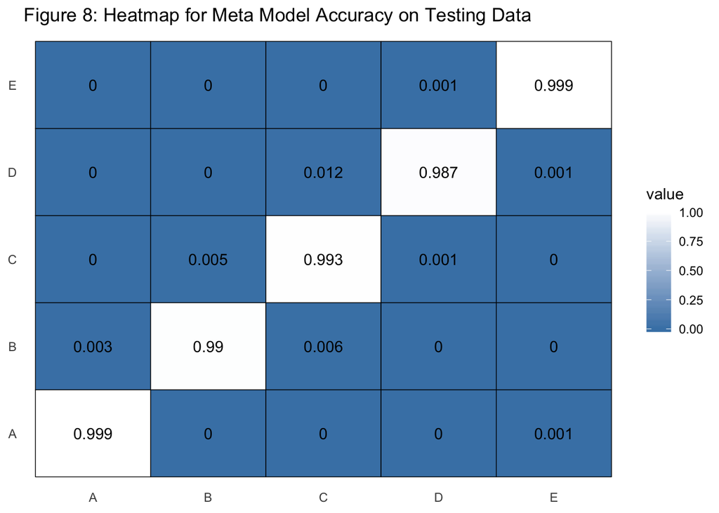

```r
melted.multi <- melt(conf.multi$table/colSums(conf.multi$table))
plot.multi <- ggplot(data.frame(melted.multi),
                    aes(x=Prediction, y=Reference, fill=value)) +
  geom_tile(color = 'black', size = 0.25) +
  scale_fill_gradient(low = "steelblue",high = "white", limits = c(0,1)) +
  ggtitle("Figure 8: Heatmap for Meta Model Accuracy on Testing Data") +
  geom_text(aes(label=round(value,3))) +
  theme(axis.title = element_blank(),
        panel.background = element_blank(),
        axis.ticks = element_blank())
plot.multi
```

## 5. Summary

Both random forest and bagged trees models perform extremely well, though the random forest performed slightly better at $\kappa$ = 0.993 to bagged trees’ 0.988. The meta model performed no better. For such an approach, it may be more effective to select models which perform similarly well but use algorithms that are more disparate than what we have chosen, though there is little room for improvement.

## 6. Notes

This analysis was generated using OSX 10.14.5, RStudio v1.1.463 and the following packages:

- caret v6.0-81
- ggplot2 v3.1.0
- kableExtra v1.0.1
- knitr v1.22
- magrittr v1.5
- mice v3.6.0
- nnet v7.3-12
- randomForest v4.6-14
- reshape2 v1.4.3
- scales v1.0.0
- tidyverse 1.2.1